# EVAR limb occlusion data

Martin Hennessy

2024-01-05

# 1 Scope of data

The following visualisations and statistics have been produced by assessing data on 1002 elective EVAR performed between 19 September 1996 and 22 December 2023.

# 2 Number of EVARs being performed

The number of EVAR performed per year and five year group are shown on the two charts below:

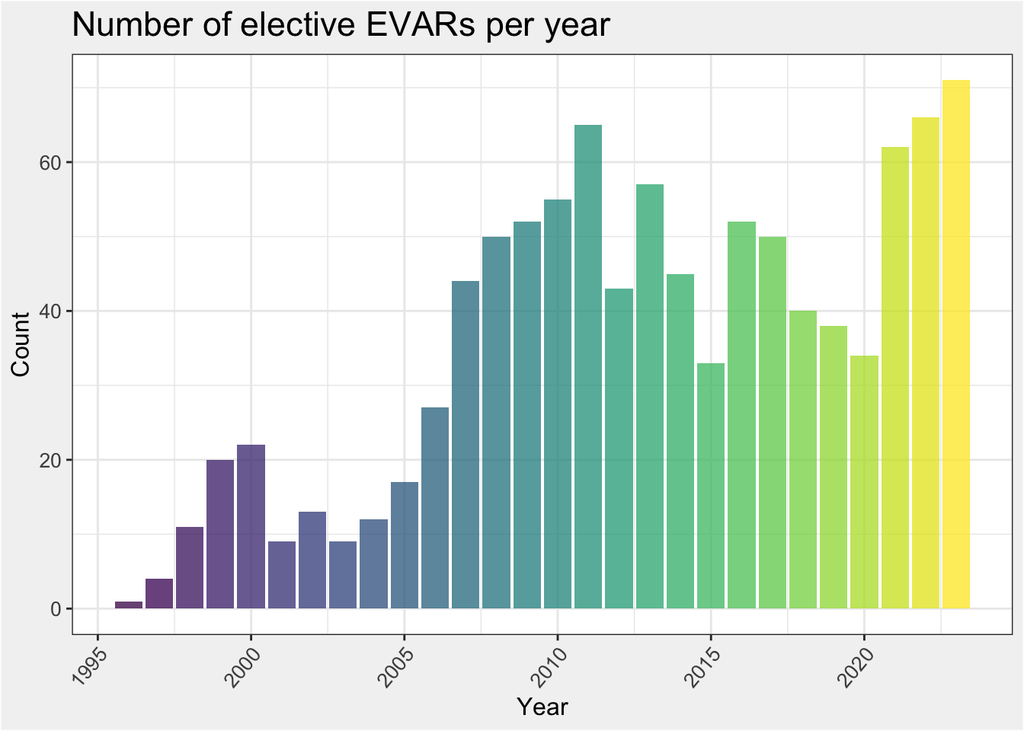

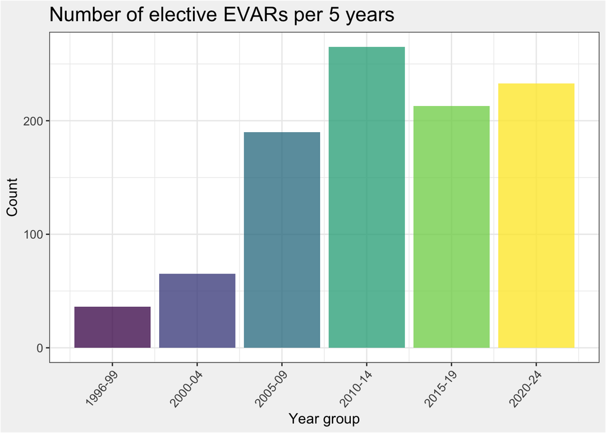

# 3 Iliac seal

- Note, when representing iliac seal in the following tables and charts, ‘IBD’ denotes use of an iliac branch device and so distal seal will be in the EIA in all these cases.
- Where the term AUI (aorto-uni-iliac) is used, it means that on that particular side (left vs right), NO iliac seal was obtained as it would have been occluded.
- CIA means common iliac artery & EIA means external iliac artery seal.

Of the 1002 EVARs, iliac seal has been obtained in the following regions:

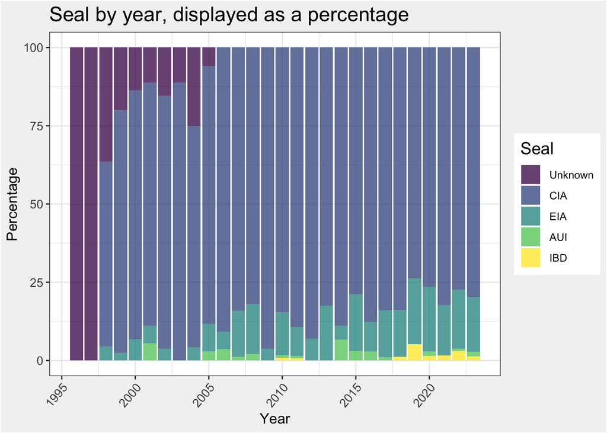

As an alternative way of visualising these data, the following table shows the number and percentage of seals by five year group:

|  | *Year group* **1996-99**, N = 72<sup>1</sup> | *Year group* **2000-04**, N = 130<sup>1</sup> | *Year group* **2005-09**, N = 380<sup>1</sup> | *Year group* **2010-14**, N = 530<sup>1</sup> | *Year group* **2015-19**, N = 426<sup>1</sup> | *Year group* **2020-24**, N = 466<sup>1</sup> | **Overall**, N = 2,004<sup>1</sup> |  |
| --- | --- | --- | --- | --- | --- | --- | --- | --- |
| Seal |  |  |  |  |  |  |  |  |
| Unknown | 26 (36%) | 20 (15%) | 2 (0.5%) | 0 (0%) | 0 (0%) | 0 (0%) | 48 (2.4%) |  |
| CIA | 44 (61%) | 103 (79%) | 333 (88%) | 463 (87%) | 350 (82%) | 369 (79%) | 1,662 (83%) |  |
| EIA | 2 (2.8%) | 6 (4.6%) | 39 (10%) | 57 (11%) | 65 (15%) | 84 (18%) | 253 (13%) |  |
| AUI | 0 (0%) | 1 (0.8%) | 6 (1.6%) | 8 (1.5%) | 6 (1.4%) | 4 (0.9%) | 25 (1.2%) |  |
| IBD | 0 (0%) | 0 (0%) | 0 (0%) | 2 (0.4%) | 5 (1.2%) | 9 (1.9%) | 16 (0.8%) |  |

<sup>1</sup> n (%)

# 4 Iliac/limb occlusions

## 4.1 Basic numbers and proportions

Limb occlusions rate overall is 4.4%.

This can be broken down into five years groups below:

|  | *Year group* **1996-99**, N = 72<sup>1</sup> | *Year group* **2000-04**, N = 129<sup>1</sup> | *Year group* **2005-09**, N = 374<sup>1</sup> | *Year group* **2010-14**, N = 522<sup>1</sup> | *Year group* **2015-19**, N = 420<sup>1</sup> | *Year group* **2020-24**, N = 462<sup>1</sup> | *Year group* **Overall**, N = 1,979<sup>1</sup> |
| --- | --- | --- | --- | --- | --- | --- | --- |
| Occluded | 2 (2.8%) | 5 (3.9%) | 18 (4.8%) | 47 (9.0%) | 7 (1.7%) | 9 (1.9%) | 88 (4.4%) |

<sup>1</sup> n (%)

The number of occlusions per individual year is better visualised as a chart:

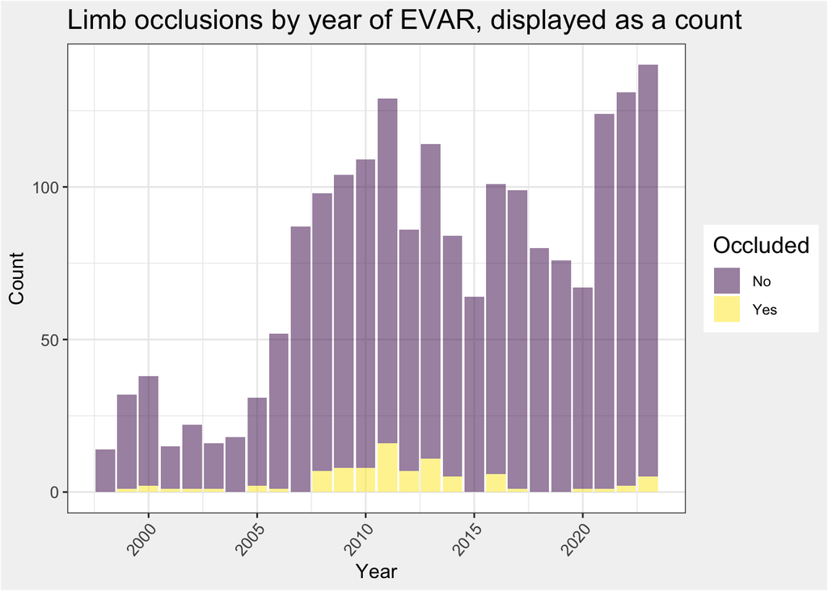

As the number of limbs inserted each year varies widely, it can be more useful to visualise occlusions as a rate rather than as an absolute number.

The chart below therefore visualises the proportion of limb occlusions per year:

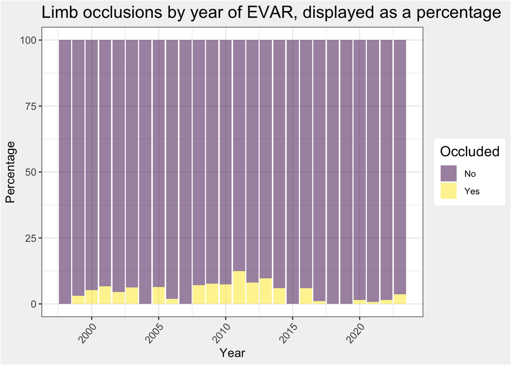

Note that more recent cases have had a much shorter follow up time in which to occlude. Time to occlusion will be explored later.

Using the mean limb occlusion rate and assuming there is no reason why limb occlusion for a particular year should significantly differ from any other year, we can calculate and plot the observed and expected frequencies of limb occlusion per year.

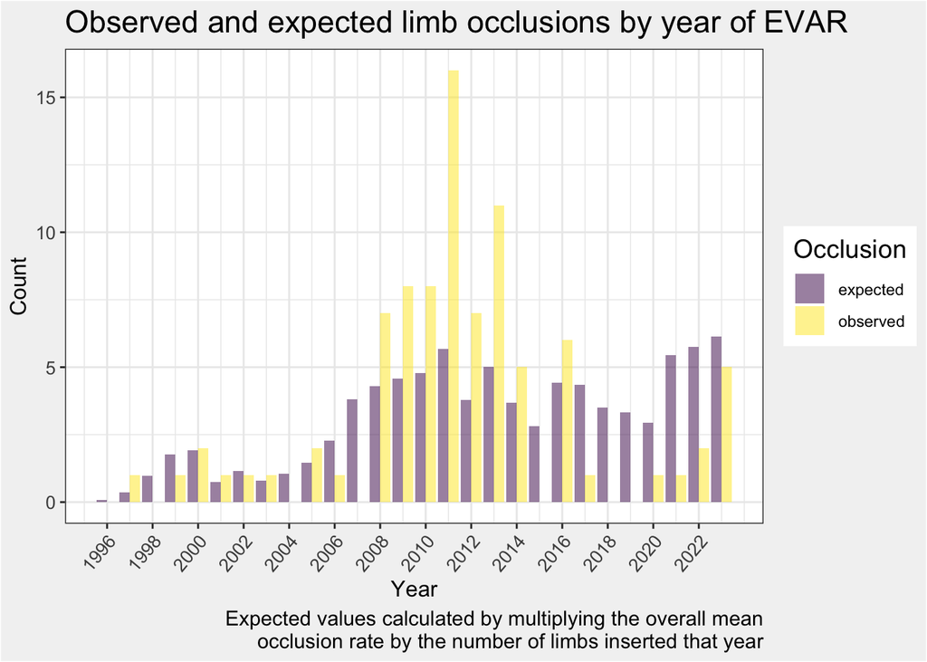

## 4.2 Limb occlusion expressed as ‘survival’

This section will use Kaplan Meier analysis to assess ‘survival’ from limb occlusion.

For simplicity, only limbs with more than 100 deployments will be included.

| Device | Count |
| --- | --- |
| Endurant II | 670 |
| Anaconda | 610 |
| Zenith | 212 |
| Talent | 148 |
| Endurant | 122 |
| Excluder | 108 |

Limb occlusion rate in this group is 4.6% (1846 limbs).

Limb occlusion survival is shown in the plot below:

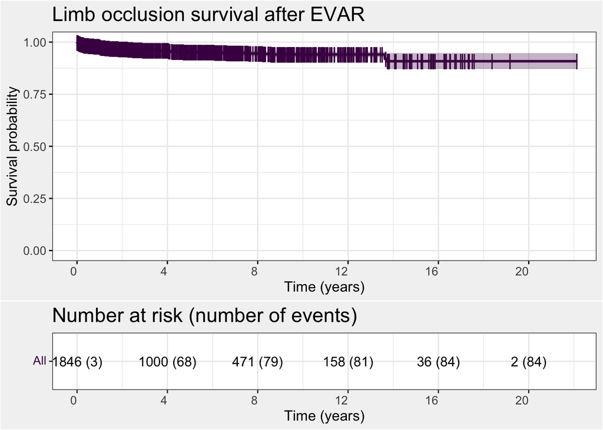

As limb occlusion rate is so low, the y-axis will be compressed on the following charts. Pay close attention to the y-axis to avoid errors in interpretation.

### 4.2.1 Limb occlusion by year group when EVAR was performed

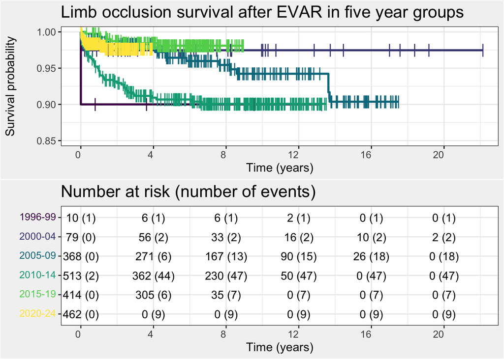

### 4.2.2 Limb occlusion by patient’s sex

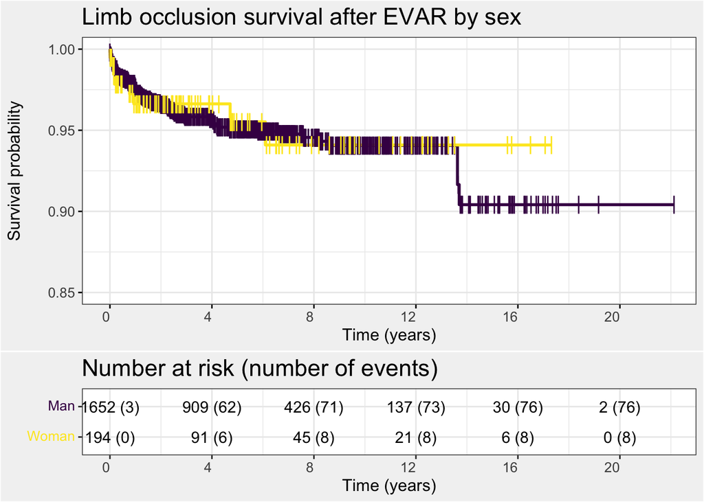

There is clearly no difference between the groups, which can be confirmed with a Log-Rank test - *p* = 0.91

### 4.2.3 Limb occlusion by limb side

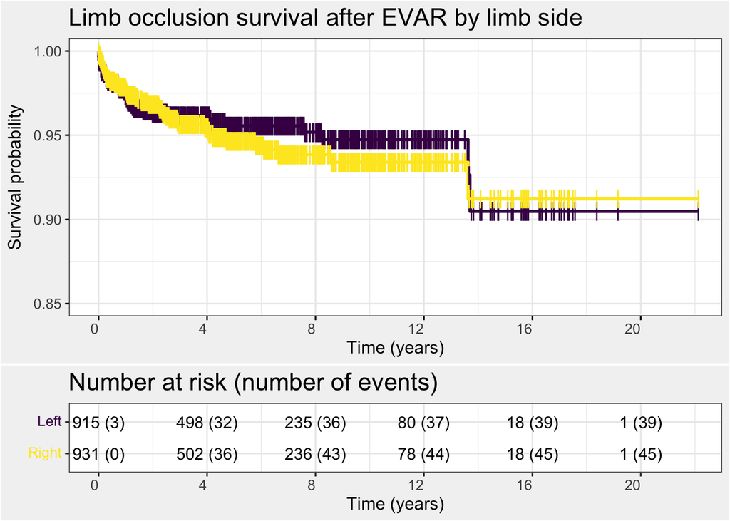

There is clearly no difference between the groups, which can be confirmed with a Log-Rank test - *p* = 0.56

### 4.2.4 Limb occlusion by seal location

All IBDs seal in EIA - these have been combined.

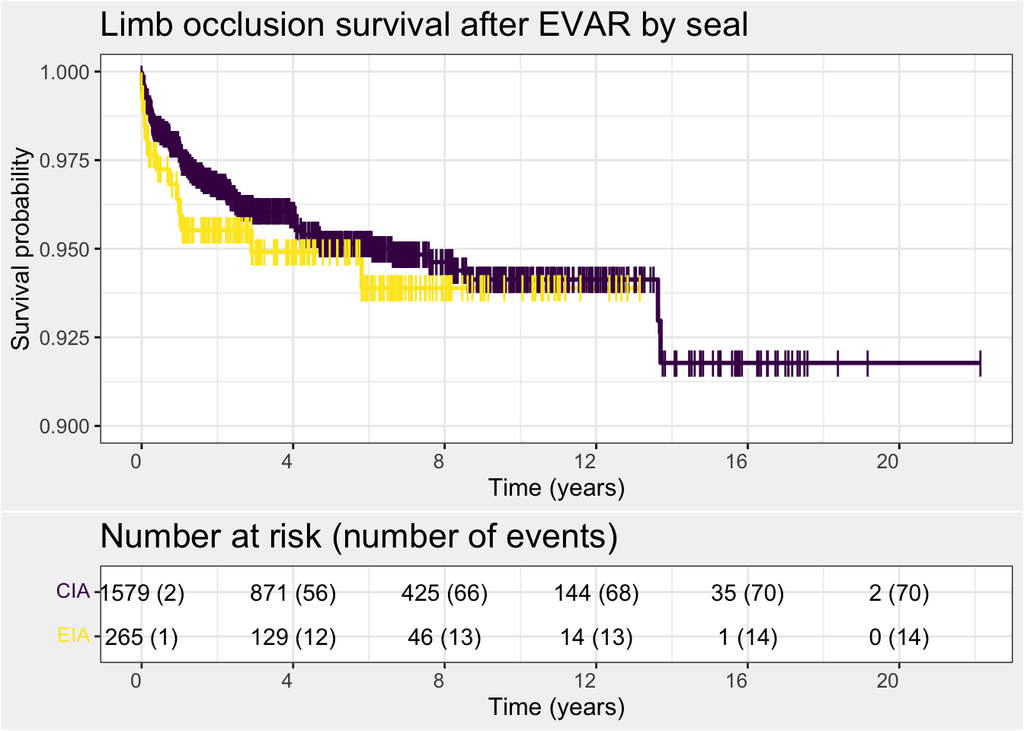

There is no difference between the groups, which can be confirmed with a log rank test - *p* = 0.36

### 4.2.5 Limb occlusion by device

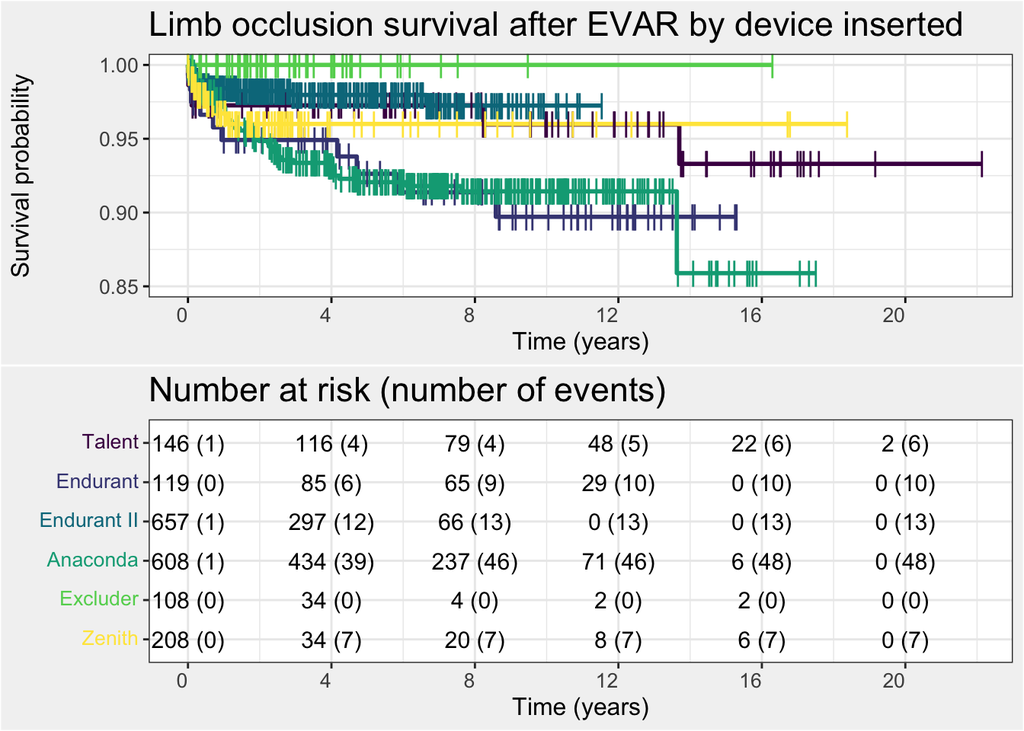

Differences between these groups are hard to detect visually. Pairwise Log-Rank test highlights the differences:

```
##
##  Pairwise comparisons using Log-Rank test
##
## data:  occlnKmData and Device
##
##             Talent Endurant Endurant II Anaconda Excluder
## Endurant    1.0000 -        -           -        -
## Endurant II 1.0000 0.0492   -           -        -
## Anaconda    0.8350 1.0000   0.0016      -        -
## Excluder    1.0000 0.2344   1.0000      0.1956   -
## Zenith      1.0000 1.0000   1.0000      1.0000   0.6756
##
## P value adjustment method: bonferroni
```

There are significant differences between Endurant and Endurant II (Endurant II has lower limb occlusion rates) and between Anaconda and Endurant II (again, Endurant II has lower limb occlusion rates).

Despite having zero limb occlusions, there is no significant difference between Excluder and any device, presumably at least in part due to the relatively low number of Excluder limbs inserted.

#### 4.2.5.1 Anaconda and Endurant II visually

To pick out the difference in these two stent-grafts, they have been plotted separately. Comparisons with the Endurant stent-graft have not been made as this stent-graft has been replaced with Endurant II and so is no longer being inserted.

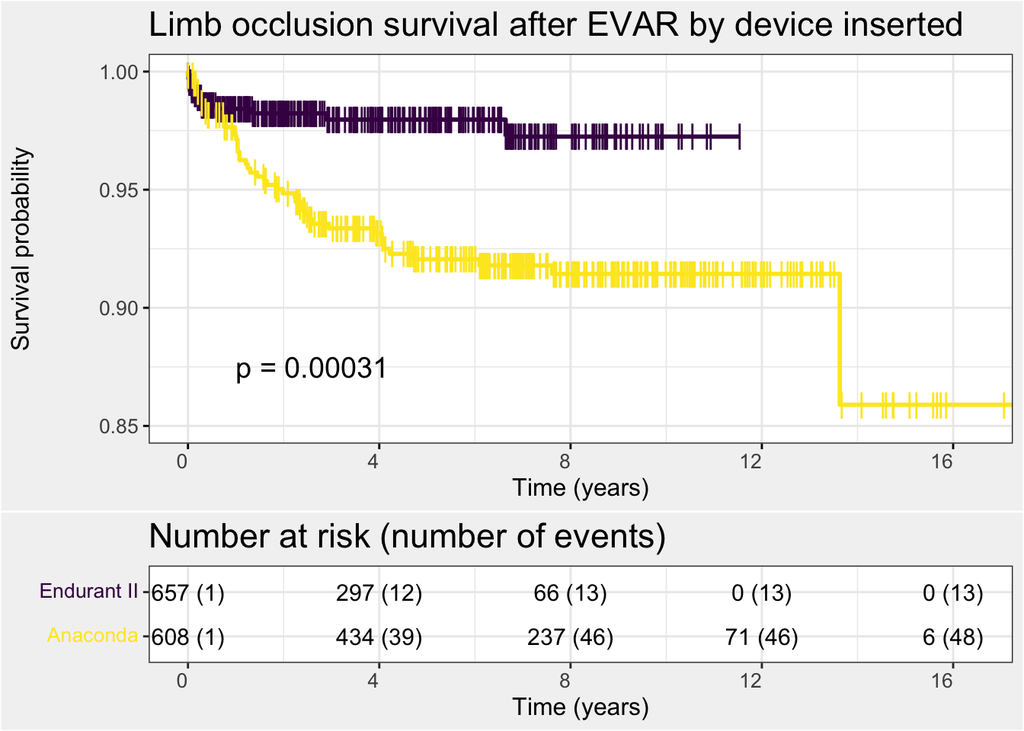

The *p* value differs from above as the initial Log-Rank was a six way comparison with Bonferroni correction whereas the one on the chart is just a two way comparison.

## 4.3 Time to limb occlusion

By only charting limbs which occlude and flipping the chart to show time to event, we can visualise when limb occlusions occur.

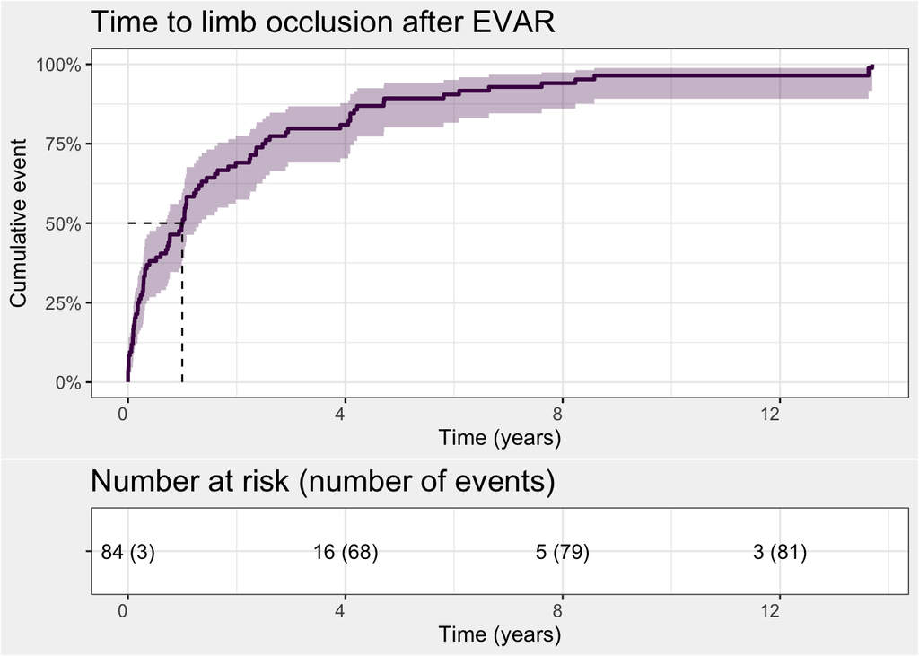

Median time to occlusion is 364.5 days and >75% of occlusions have happened by four years. We can use this information to contextualise the chart in section 4.1 (ie. the very recent years with low occlusion rates are probably not low simply because they are recent).